# Home-made or imported: on the possibility for renewable electricity autarky on all scales in Europe

Tim Tröndle

Stefan Pfenninger

Johan Lilliestam

v1.0

The original version of this article has been published in Energy Strategy Reviews.

# Abstract

Because solar and wind resources are available throughout Europe, a transition to an electricity system based on renewables could simultaneously be a transition to an autarkic one. We investigate to which extent electricity autarky on different levels is possible in Europe, from the continental, to the national, regional, and municipal levels, assuming that electricity autarky is only possible when the technical potential of renewable electricity exceeds local demand. We determine the technical potential of roof-mounted and open field photovoltaics, as well as on- and offshore wind turbines through an analysis of surface eligibility, considering land cover, settlements, elevation, and protected areas as determinants of eligibility for renewable electricity generation. In line with previous analyses we find that the technical-social potential of renewable electricity is greater than demand on the European and national levels. For subnational autarky, the situation is different: here, demand exceeds potential in several regions, an effect that is stronger the higher population density is. To reach electricity autarky below the national level, regions would need to use very large fractions or all of their non-built-up land for renewable electricity generation. Subnational autarky requires electricity generation to be in close proximity to demand and thus increases the pressure on non-built-up land especially in densely populated dense regions where pressure is already high. Our findings show that electricity autarky below the national level is often not possible in densely populated areas in Europe.

**Keywords**: localism; cooperation; land use; potential; administrative division; eligibility

# 1 Introduction

Renewable electricity, nuclear power, and carbon capture and storage are the main supply-side options to decarbonise the electricity system in Europe. Among these three, renewable electricity is the only option to not deplete the energy resource it depends on, but its resource has another unique characteristic: it is available everywhere, in different intensities. This makes it possible to generate electricity from local resources and decrease imports — and it could allow regions to become electricity autarkic, i.e. eliminating imports altogether. This would be in stark contrast to today’s situation, in which the European Union relies on primary energy imports for more than a third of its electricity [1], and in which Member States trade significant amounts of primary energy and electricity within the European Union. A transition to renewable electricity might hence not only allow the European Union, its Member States, or regions in Europe to decarbonise their electricity systems but also to become autarkic.

Proponents of local electricity generation bring up the benefits of increased electricity security, improvements to the local economy and its sustainable development, and community involvement. Local generation is seen as a reliable source of electricity, with supply and price determined within a political unit’s own borders. As such, autarky would decrease dependency on others and increase electricity security [2]. Positive effects on the local economy are expected, as value creation happens within the region, thus decreasing the outflow of capital. Installation of generators, and their maintenance and operation, are furthermore expected to create jobs locally [2,3]. The resulting increase in economic activity will improve the attractiveness of the regions and thereby counteract emigration from peripheral regions to the cities [2,3]. Lastly, [4,5] show that self-sufficiency is important to the local community, and [3,6] discuss case studies, in which the involvement of the local community in transition processes has improved the willingness to change and has reduced public opposition.

There are also arguments against local autarky, in particular concerning the cost and stability of small electricity systems. Larger renewable electricity systems often have lower costs, because of a more efficient use of resources and because the best renewable resources can be used by everybody – whereas in an autarkic setting, one must use what is available locally, regardless of the quality. Electricity demand may rise due to a less efficient use of resources, for example when electricity cannot be used or stored locally at the time it is generated [7–11]. Positive effects on the local economy through local value creation will be diminished, or eliminated, as both technology and know-how for installation and operation will often need to be imported from other regions or countries — the specialist knowledge is not readily available everywhere. Lastly, the land footprint for electricity generation is high and can lead to land use conflicts, for example with local food or feed production [12]. Thus, some authors have pointed out that the benefits of cooperation and autarky can be combined when full autarky is replaced by local generation embedded in a larger system [11,13].

Because there are advantages and disadvantages, there is no consensus in European policy as to which degree local generation should be promoted or integration should be strengthened. On the one side, there are many initiatives on the global (Go 100% Renewable Energy, Global 100%RE), European (100% RES communities, RURENER), and national levels (CLER, Community Energy Scotland, 100ee Regionen Netzwerk) that promote local generation as part of their agendas. Autarky is often discussed in an on-going debate about decentralisation of the electricity system [14–16], but decentralisation (in terms of plant sizes, grid structures, and ownership) and autarky are distinct aspects of the electricity system: decentralised systems are not necessarily autarkic, and autarkic systems must not be decentralised. Existing projects are often in rural areas, while for cities and towns it is acknowledged that autarky will be more difficult and thus, they are advised to focus on improving energy efficiency instead [17]. While these initiatives promote local generation, they do as well promote cooperation, but only on the regional level: between municipalities [18,19], and in particular between cities and their encompassing rural municipalities [17].

On the other hand, the European Commission and the European Network of Transmission System Operators for Electricity (ENTSO-E) strive for stronger electricity cooperation in Europe. While they do not oppose local generation, they both emphasise the benefits, especially the cost-decreasing effect, of integration and electricity trading among European countries [20,21]. Thus, the Commission is striving for the establishment of a single internal energy market through the harmonisation of market mechanisms, support schemes, and network codes. Regarding autarky on the European level, the Commission seeks to lower import dependency, but it does not target full autarky in terms of European import dependence. Instead, it aims to increase diversity of foreign energy suppliers and energy sources. With this strategy, the EU strives to increase the use of local resources, but it is certainly not striving for autarky on the national or subnational levels.

Despite the on-going debate whether Europe should strive for autarky to reach potential benefits, we do not know whether electricity autarky is possible for Europe, its nations, or regions. The source of uncertainty stems from another characteristic of renewable electricity: its large land footprint compared to other sources of electricity [22]. We know that electricity autarky at the European level or below will require large areas devoted at least partially for electricity generation, but not whether sufficient areas are available in each country, region or municipality — or, if they are, how much of the land needs to be reserved for electricity generation.

The objective of this article is to identify whether and in which places electricity autarky is at all possible in Europe, and which shares of land must be devoted to electricity generation in the cases where electricity autarky is possible.

We do this by quantifying the potential of renewable electricity with high spatial resolution and comparing it to today’s electricity demand. We consider the four administrative levels that exist in nearly all European countries: the continental, national, regional (first-level administrative division), and municipal levels. All units on all four levels have their own local governments which could, in principle, decide to declare electricity autarky. We consider onshore and offshore wind power, and photovoltaics in our analysis as these technologies have the highest potential [22], while excluding biomass and hydropower (see below). The geographic scope of our study comprises the countries with member organisations in the ENTSO-E: EU-28, EFTA without Liechtenstein, and Western Balkans countries. We ignore Iceland which has no connection to the mainland and is already electricity autarkic.

# 2 Literature Review

Arguments for or against electricity autarky in Europe are often supported through case studies for single municipalities [2,3,6,12] but research is needed on the European scale to understand on which level autarky is possible and to understand the land trade-offs that have to be made. Autarky based on renewable electricity is only possible if enough electricity can be generated locally, i.e. the annual potential for renewable electricity generation is at least as high as the annual demand. A sufficient potential is hence a necessary condition for autarky and as such a crucial aspect to consider when targeting autarky in any region. We acknowledge that, if the potential in an area is sufficient, autarky may still be impossible, impractical, or infeasible, for example when taking fluctuations of renewables into account. Here, we only discuss the necessary condition of sufficient potentials, but not whether autarky is actually feasible.

In the literature, different kinds of potentials have been assessed, for example: theoretical, geographical, technical, and economic. To analyse the possibility of autarky, the most important kind is the technical potential. It defines the amount of renewable energy that can be transformed to electricity given technological restrictions. There is however no consensus for this definition: in [23] for example, the technical potential does not include electricity that could be generated on environmentally protected areas, whereas in [24] it does. For roof-mounted PV, north-facing roof areas are sometimes included in the calculation of the technical potential [25] and sometimes not [26]. The different definitions, but also different assumptions, can lead to diverging results.

We are not aware of studies assessing technical potentials in the context of electricity autarky on the European scale, but there are studies that assess technical potentials of single technologies in Europe. For onshore wind, results differ widely, from 4,400 TWh/a [23] to 20,000 TWh/a [27] or even 45,000 TWh/a [24]. The relatively low estimate of the first study can be explained by three exclusion factors not present in the latter two studies: it excludes areas with average wind speeds below 4 m/s at 10 m hub height as well as environmentally protected areas, and it limits the use of agricultural land and forests. Combined, these constraints exclude around 90% of Europe’s land. Despite the differences in definitions, the three studies agree that onshore wind power could supply all of Europe’s current electricity demand of around 3,000 TWh/a, assuming the technical potential could be fully exploited.

Two studies assess the technical potential of roof-mounted PV at the continental level, finding potentials of 840 TWh/a [26] and 1,500 TWh/a [28]. The difference in results can be explained by different geographical scopes, by the fact that [26] ignores north-facing areas, and by different methods: while [26] uses a statistical approach to quantify available roof areas, [28] uses high resolution satellite images for a few cities in Europe to derive roof area estimates, and then extrapolates these results using population density as a proxy. Both studies show that roof-mounted PV can contribute significantly to supplying Europe’s electricity needs, albeit at a much lower magnitude than onshore wind. Combined with onshore wind, both technologies are likely able to fulfil Europe’s electricity demand entirely.

Some of the studies with European scope disaggregate their results on the national level, thus permitting an analysis of renewable electricity potential in light of national autarky [24,26,27]. Other studies have assessed the potential for single countries, e.g. wind in Germany [29], Spain [30], Sweden [31], and Austria [32]. All of those roughly agree with the results from the analyses on the continental level and reveal potentials which are close to or exceeding today’s electricity demand. Again others have assessed national potentials of roof-mounted PV, e.g. 1,262 TWh/a [33] and 148 TWh/a (residential buildings only) [34] for Germany or 18 TWh/a [35] and 53 TWh/a [25] for Switzerland. There are no such potential studies for all European countries and thus national potentials across all of Europe are available only from [24,26,27].

On the regional and municipal levels, there are some studies which assess the potentials across entire countries [29,35], but most studies focus on single regions or municipalities, e.g. [36–40]. No study has been performed that assesses renewable electricity potentials on the regional or municipal levels across all of Europe within a single consistent analysis framework.

# 3 Methods and data

We assess the possibility of electricity autarky for administrative units in Europe on four levels: continental, national, regional, and municipal. For each administrative unit on each administrative level we quantify renewable potentials and current electricity demand. We then reject autarky based on renewable electricity for those units for which annual demand exceeds annual potential. We list all data sources used in this approach in Table S1 in the supplementary material.

## 3.1 Definition of administrative levels

To identify administrative units including their geographic shape on all levels we use NUTS (Nomenclature of Territorial Units for Statistics) 2013 data [41] and the Global Administrative Areas Database (GADM) [42]. The scope of our analysis is EU-28 excluding Malta (for which no data was available), plus Switzerland, Norway, and the Western Balkans countries Albania, Bosnia and Herzegovina, Macedonia, Montenegro, and Serbia. Together, all 34 countries form the continental level; in isolation they form the national level (see Table 1). Country shapes for EU-28 countries, Switzerland and Norway are defined by NUTS 2013, and for the Western Balkans countries by GADM.

The regional level is defined by the first-level administrative divisions, e.g. cantons in Switzerland, régions in France, or oblasti in Bulgaria, of which GADM identifies 502 in the study area. Macedonia and Montenegro only have one subnational administrative level — the municipal level — which in our analysis is below the regional level. For Macedonia we use a statistical division from NUTS3 larger than the municipal level, and for Montenegro we use the municipal level from GADM as no alternative is available. Lastly, there are 122635 communes which form the municipal level. These communes are defined for most countries by the Local Administrative Unit 2 (LAU2) layer of NUTS 2013. For Albania, Bosnia and Herzegovina, Macedonia, and Montenegro, we take their definitions from GADM. Lastly, we estimate the size of maritime areas over which administrative units have sovereignty by allocating Exclusive Economic Zones (EEZ) to units on all levels. Within a country, we divide the EEZ and allocate parts to all subnational units which share a coast with the EEZ. The share is proportional to the length of the shared coast. We use EEZ shape data from [43].

Table 1: Administrative levels considered in this study.

| Level | Number units | Source of shape data |
| --- | --- | --- |
| Continental | 1 | GADM [42], NUTS [41] |
| National | 34 | GADM [42], NUTS [41] |
| Regional | 502 | GADM [42], NUTS [41] |
| Municipal | 122635 | GADM [42], LAU [41] |

## 3.2 Renewable electricity potential

To quantify the renewable electricity potential in each administrative unit, we first estimate the surface areas eligible for generation of renewable electricity and then the magnitude of electricity that can on average be generated annually on the eligible surfaces by on- and offshore wind turbines and open field and roof-mounted photovoltaics. We assess two types of potentials of renewable electricity: the technical potential and a socially constrained potential. The only difference between these potentials is the classification of surface eligibility, i.e. the surface areas available for renewable electricity generation. We furthermore assess land requirements when assuming electricity autarky, i.e. the amount of non-built-up land that is needed for electricity generation to become autarkic.

In our study we do not consider two types of renewable electricity that could contribute to supplying Europe’s electricity demand: hydropower and biomass. We ignore hydropower, because its potential is largely exhausted in Europe [44] and no major new contributions can be expected in the future. We ignore biomass for two reasons: first, its power density in Europe (<0.65 MW/km<sup>2</sup> [45]) is lower than the one from wind or solar power and thus wind turbines and open field photovoltaics are always superior in terms of electricity yield per area. Second, we also do not consider combining wind power and biomass production despite the high electricity yield per area because of land use conflicts with food and feed production that biomass production causes.

### 3.2.1 Open field surface eligibility

To decide which fractions of the land and water surfaces of an administrative unit can be used for open field PV, or on- and offshore wind farms, we divide Europe into a 10 arcsecond grid, whose cell size varies with the latitude but never exceeds 0.09 km<sup>2</sup>. For each cell we obtain the current land cover and use from the GlobCover 2009 dataset [46], the average slope of the terrain from SRTM and GMTED [47,48] or its maximum water depths from ETOPO1 [49], and whether it belongs to an area which is environmentally protected from the World Database on Protected Areas [50]. We additionally use the European Settlement Map (ESM) with 6.25 m<sup>2</sup> resolution [51] to classify an entire 10 arcsecond cell as built-up area if more than 1% of its land area are buildings or urban parks. We use land cover and use, slope, protected areas, and settlements as decision criteria because these constraints have been found to be the most relevant for land eligibility studies in Europe [52]. For each potential type there is a set of rules by which we define if a cell is eligible for renewable electricity generation and if it is, which technology type it is used for. We assume that a cell is always used for a single technology only, based on the rules described below.

### 3.2.2 Roofs for PV

The potential for roof-mounted PV not only depends on the amount of roof area available, but also on the orientation and the tilt of these roofs. We analytically derive rooftop area in each administrative unit. We then use a dataset of Swiss roofs, taking it as representative for Europe as a whole, to correct the area estimation and to statistically amend it with tilt and orientation.

We use the European Settlement Map [51] to identify the amount of rooftop area in each administrative unit. The map is based on satellite images of 2.5 m resolution and employs auxiliary data e.g. on population or national data on infrastructure to automatically classify each cell as building, street, urban green, etc. For each 10 arcsecond cell we sum up the space that is classified as buildings. We consider only those cells that we initially classified as built-up areas before, and which are hence not used for other renewable generation.

We then amend this first estimation with data from sonnendach.ch for Switzerland [53]. We use this dataset in two ways. First, we improve the area estimation taken from the European Settlement Map. Sonnendach.ch data is based on high-resolution 3D models of all buildings in Switzerland and thus allow for estimations of roof areas with high accuracy. For the roofs included in the sonnendach.ch dataset, the European Settlement Map identifies 768 km<sup>2</sup> building footprints, where sonnendach.ch finds 630 km<sup>2</sup> roof area. Sonnendach.ch also apply expert estimation of unavailable parts of the roof, e.g. those covered with windows or chimneys [54], which reduces the theoretically available rooftop areas from 630 km<sup>2</sup> to 432 km<sup>2</sup>. Thus, for Switzerland, the realistic potential may be only 56% of the building footprints from ESM. We assume this factor is representative for all Europe and apply the factor of 0.56 to all areas identified by the European Settlement Map.

The second use we make of the Swiss data is to identify the tilt and orientation of the roof areas. For that, we cluster all roofs in 17 categories: flat roofs, and roofs with south-, west-, north-, and east-wards orientation, each with four groups of tilt. We then quantify the relative area share of each category (see Table S2 in the supplementary material). Again, we assume the distribution of these attributes of the Swiss housing stock is representative for Europe and apply it to all administrative units.

### 3.2.3 Renewable electricity yield

Based on the previous steps we can quantify the surface area eligible for renewable electricity generation in each grid cell. To estimate the annual generation for wind power, we first assume a capacity density of 8 MW/km<sup>2</sup> (15 MW/km<sup>2</sup>) based on a rated capacity of 2 MW/unit (10 MW/unit) for onshore (offshore) wind [24] which allows us to derive the installable capacity for each grid cell. We then simulate renewable electricity yield of the years 2000–2016 on a 50km<sup>2</sup> grid over Europe from Renewables.ninja [55] to determine the average annual electricity yield from installable capacity on each 10 arcsecond grid cell. We assume onshore (offshore) wind turbines are available 97% (90%) of the time [24].

For open field PV and flat roof-mounted PV, we assume a capacity density of 80 MW<sub>p</sub>/km<sup>2</sup> based on a module efficiency of 16% and space demand of two times the module area as an average for all Europe. Furthermore, we assume modules are installed southward facing and with tilt optimisation as defined by [56]. For PV of tilted roofs, we assume a capacity density of 160 MW<sub>p</sub>/km<sup>2</sup> based on a module efficiency of 16%. Using the statistical model from Table S2 we define 16 different deployment situations. We then use Renewables.ninja [55,57] to simulate the renewable electricity yield of the years 2000–2016 of each deployment situation on the 50km<sup>2</sup> grid. We assume a performance ratio of 90%.

### 3.2.4 Technical potential

We first assess the technical potential which is only restricted by technological constraints. To quantify it, we use the following rules: We allow wind farms to be built on farmland, forests, open vegetation and bare land with slope below 20° (slope constraint taken from [27]). An example of exclusion layers for Romania is shown in Figure 1 (see Supplementary Material for exclusion layers of all 34 countries in this study). We furthermore allow open field PV to be built on farmland, vegetation and bare land with slope below 10° (slope constraint taken from [58]). In grid cells where both onshore wind farms and open field PV can be built, we choose the option with the higher electricity yield. Lastly, we allow offshore wind farms to be built in water depths of less than 50m. Grid cells identified as built-up area cannot be used for open field PV or wind farms, only for roof-mounted PV.

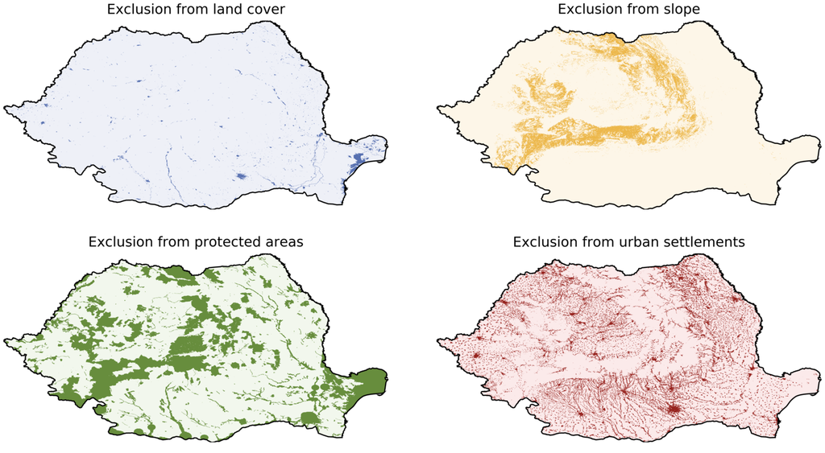

Figure 1: Exclusion layers for determining the potential of wind power in Romania: shaded areas are not available for electricity generation (technical potential ignores protected areas).

### 3.2.5 Technical-social potential

The technical potential defines an upper bound to the electricity that can be generated in each administrative unit. However, it is a strong overestimation of a realistic potential: in our case, it allows onshore wind and open field PV to be built on all environmentally protected areas, which might not only have severe consequences for the local flora and fauna, but may also breach the directives on habitats [59] and birds [60] of the European Union in addition to national and regional laws. The technical potential also allows open field PV to be built on farmland causing land use conflicts with food and feed production, much like the problems with biomass. Finally, it permits use of all eligible surfaces, potentially leading to very high densities of electricity generation. In some parts of Europe this leads to all eligible surfaces being covered with PV modules or wind turbines, which is not realistic.

We therefore introduce a socially and ecologically constrained potential, in which we prohibit the use of environmentally protected surfaces and prohibit open field PV on farmland. Open field PV can only be built on bare and unused land. Furthermore, we assume that only 10% of all available surface area can be used for renewable power generation, including water surface for offshore wind. We do still allow the use of all eligible roof areas for the generation of solar power, as there is little conflict potential in that case. We test the impact of this assumption in the results section. Table 2 lists the differences in the definition of the technical potential and the technical-social potential.

Table 2: Differences between the technical potential and the technical-social potential.

|  | Technical potential | Technical-social potential |
| --- | --- | --- |
| Protected areas usable | yes | no |
| PV on agricultural land | yes | no |
| Eligible land usable | 100% | 10% |
| Eligible water surfaces usable | 100% | 10% |
| Eligible roof areas usable | 100% | 100% |

### 3.2.6 Land footprint

Finally, we assess the amount of land necessary to reach electricity autarky. This allows us to study one important implication of electricity autarky: its land foot print. Furthermore, assessing the land necessary for electricity autarky reduces uncertainty compared to assessing the technical-social potential. Quantifying the potential for every administrative unit in Europe has large uncertainties: the assessment is very sensitive to some of the assumptions which in turn may vary between regions in Europe and which are highly uncertain, in particular the amount of eligible land that can be used for electricity generation [32]. When we assess the necessary land surface, we do not need to make this assumption: instead, it is the result of our analysis.

We assume most of the technical potential to be available but we prohibit open field PV on farmland. Because we focus on land use and to avoid making assumptions on availability of water surfaces, we ignore offshore wind potentials. We prioritise roof-mounted PV as it does not require land: first, we fulfil demand as much as possible with electricity from roof-mounted PV. Then, we compare the remaining demand to the potential of open field PV and onshore wind to derive the share of the non-built-up land that is necessary to fulfil demand with renewable electricity which is generated locally.

## 3.3 Current electricity demand

We relate the renewable electricity potential to current electricity demand. We use country-wide demand data from 2017 for each country [61] from ENTSO-E. For subnational levels, we allocate the national demand based on population distribution and the size and location of electricity-intensive industries. We subtract industrial demand of electricity intensive industry from national demand and assume the remainder is spatially distributed over the country proportionally to population. We hence assume that each person in each country is on average responsible for the same amount of electricity demand from non-electricity intensive industries, commerce, and households. We use the Global Human Settlement Population Grid which maps population in 2015 with a resolution of 250 m [62] in Europe and globally. It is based on national census data and population registers. With that, we define the local, annual electricity demand in each administrative unit of each administrative level.

We derive a dataset of electricity intensive industries from the European Emission Trading Scheme (ETS) [63]. Using ETS data means we are neglecting industries in Switzerland and the Western Balkan countries which do not take part in the scheme. We consider only steel, aluminium, and chloralkali process facilities, which are individually responsible for more than 0.5% of the respective ETS activity (covering ~90% of all activity). Based on the ETS address registry and manual research, we identify the exact location of those facilities.

As there is no comprehensive and consistent dataset for industrial production, we make two important assumptions to determine each installation’s production and hence electricity demand. First, we assume that the product output of each plant is homogenous, corresponding to “steel”, “aluminium”, etc. We do thus not differentiate between types of steel or aluminium products. Each product comes with a generic electricity intensity factor (MWh/t output) which we derive from [64–69]. Second, we assume that the production of each facility is directly proportional to its emissions: a factory emitting 10% of the ETS activity’s CO<sub>2</sub> emissions (after all installations contributing 0.5% or less have been removed) is assumed to produce 10% of the output of all facilities in the filtered list under each ETS activity. To quantify annual European production we take industry organisation data [65,66,68–70] for the most recent year available. For chloralkali plants, we assume the lowest electricity intensity in the range given by [67], given the efficiency improvements (-8% intensity reduction since 2001) over the last decade [69].

# 4 Results

## 4.1 Technical potential

On the **continental level**, the technical potential of roof-mounted PV, open field PV, and on- and offshore wind is vast: technically, these technologies could generate almost 230,000 TWh/a. This exceeds the continental demand of 3,200 TWh/a in 2017 more than 70 times. The largest contribution comes from open field PV (66%), followed by offshore and onshore wind.

On the **national level**, the technical potential exceeds demand in all countries, but the potentials and the density of demand are unevenly distributed across the continent. For example, the technical potential in Latvia exceeds demand 400 times, whereas it is only 5 times higher than national demand in Switzerland (when considering wind and solar power only, but not hydropower).

On the **regional level**, the technical potential is sufficient for almost all regions. In a few cases — the first-level administrative units with all or most of their area within densely populated city borders (Brussels, Basel, Oslo, Vienna, and Berlin) — the potential is insufficient; further, a number of cities (e.g. Bucharest, Geneva, Budapest, and Prague) have potentials only slightly higher than their demand. Hence, on this level, resource constraints start to become an issue in a few cases, but generally, the technical potential is still high enough in almost all regional cases.

Despite the vast continental potential, the **municipal level** sometimes shows technical potentials which are too small to allow for autarky. Although almost all — about 97% — of municipalities have a technical potential exceeding current demand (see Figure 2), about 14% of Europe’s population would be undersupplied. It is largely an issue of densely populated municipalities: 98% of the impacted population lives in municipalities with a population density higher than 1000 people per km<sup>2</sup>. Using the definition of the European Commission and the OECD of the degree of urbanisation (DEGURBA) [71], 91% of the impacted population lives in cities, 9% in towns and suburbs, and none in rural areas.

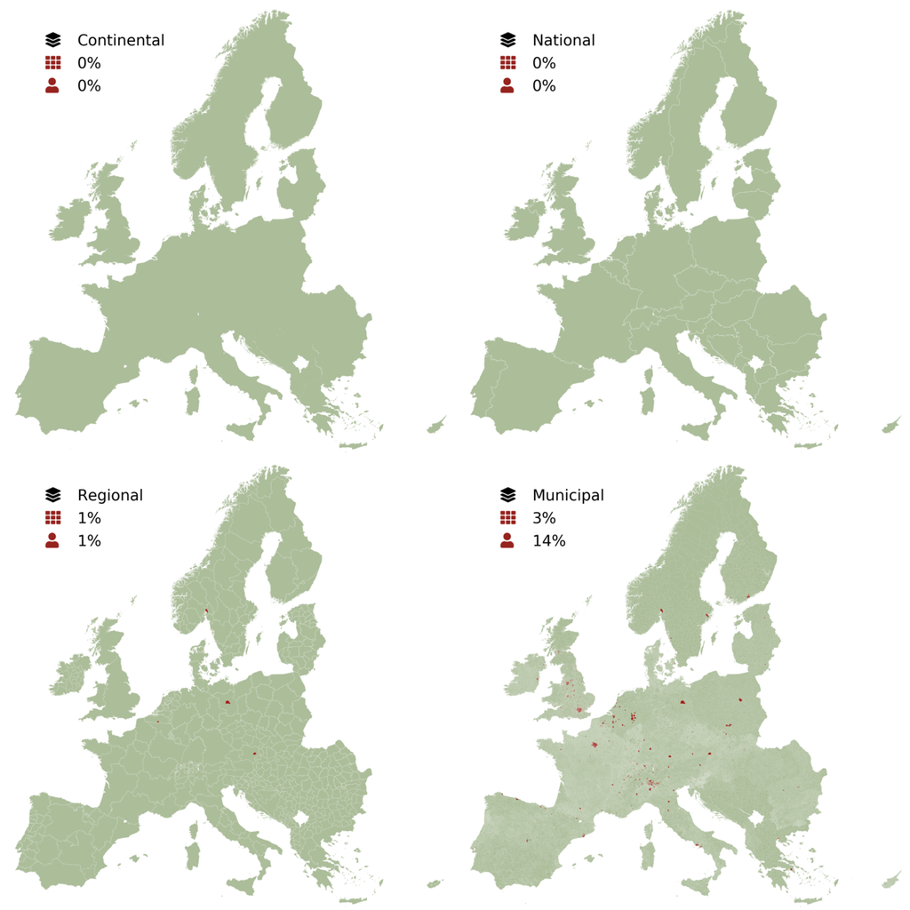

Figure 2: Administrative units where the technical potential exceeds electricity demand (light/green) and where it does not (dark/red), on all four administrative levels. For each level the text box furthermore shows from top to bottom: the name of the level, the fraction of undersupplied administrative units, and the fraction of the European population living in undersupplied administrative units.

Figure 3 shows the ranges of relative technical potential for all countries when assuming autarky on the municipal level. It shows how some countries have better prerequisites for electricity autarky on this level than others: in Montenegro for example, almost everyone lives in municipalities with very high potential; a situation which is similar in other Balkans countries and Cyprus. Other countries like Switzerland, United Kingdom, Ireland, and Greece have a quarter of their population living in municipalities with a potential lower than or close to their current demand, making municipal level autarky impossible. The figure furthermore shows that the relative potential varies largely within countries: in Greece for example, despite the low potential it has to offer for a quarter of its population, the majority of the remaining population lives in municipalities where the potential exceeds demand 30 times. Countries with such high variability could pool resources and seek autarky for sets of municipalities — combining those with low potential with neighbouring municipalities with high potential to achieve sufficient supply for all.

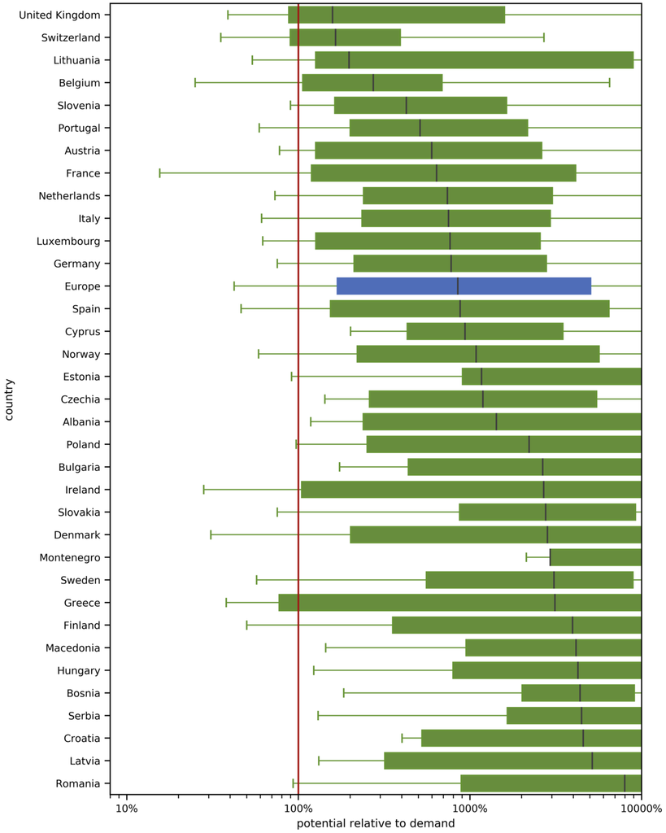

Figure 3: Distribution of technical potential per country and all of Europe as experienced by the population when considering autarky on the municipal level: the boxes show the potential of the municipalities in which half of the population lives; centred around the median. Whiskers (green lines) show 95% of the population. Outliers (2.5% below and above each whisker) are not depicted.

## 4.2 Technical-social potential

When applying the constraints of the technical-social potential, the total potential on the **continental level** is 15,000 TWh/a and hence exceeds today’s electricity demand more than 4 times. As the constraints do not limit roof-mounted PV, this is now the dominant technology (33%), followed by onshore wind, open field PV, and offshore wind. Even with strict social constraints, reducing the technical potential by over 90%, Europe’s potential for renewable electricity is high enough for Europe to enable electricity autarky on the continental level.

On the **national level**, every country still has sufficient autarky potential: while the technical-social potential, similar to the technical potential, is not equally distributed over Europe, even the lowest relative potential (Switzerland) is 30% higher than national demand. Again, we find the highest relative potential in Latvia (2200% of national demand).

On the **regional level**, we find the lowest relative potentials in subnational regions within city borders. Oslo reveals the lowest potential, where less than a quarter of demand can be supplied by local renewable generation. Other urban areas also have an insufficient technical-social potential, including the Île-de-France (Paris) region, Dublin, and Berlin (see Figure 4). Almost all — 96% — of the 502 first-level administrative units holding 95% of Europe’s population have a technical-social potential exceeding their current demand.

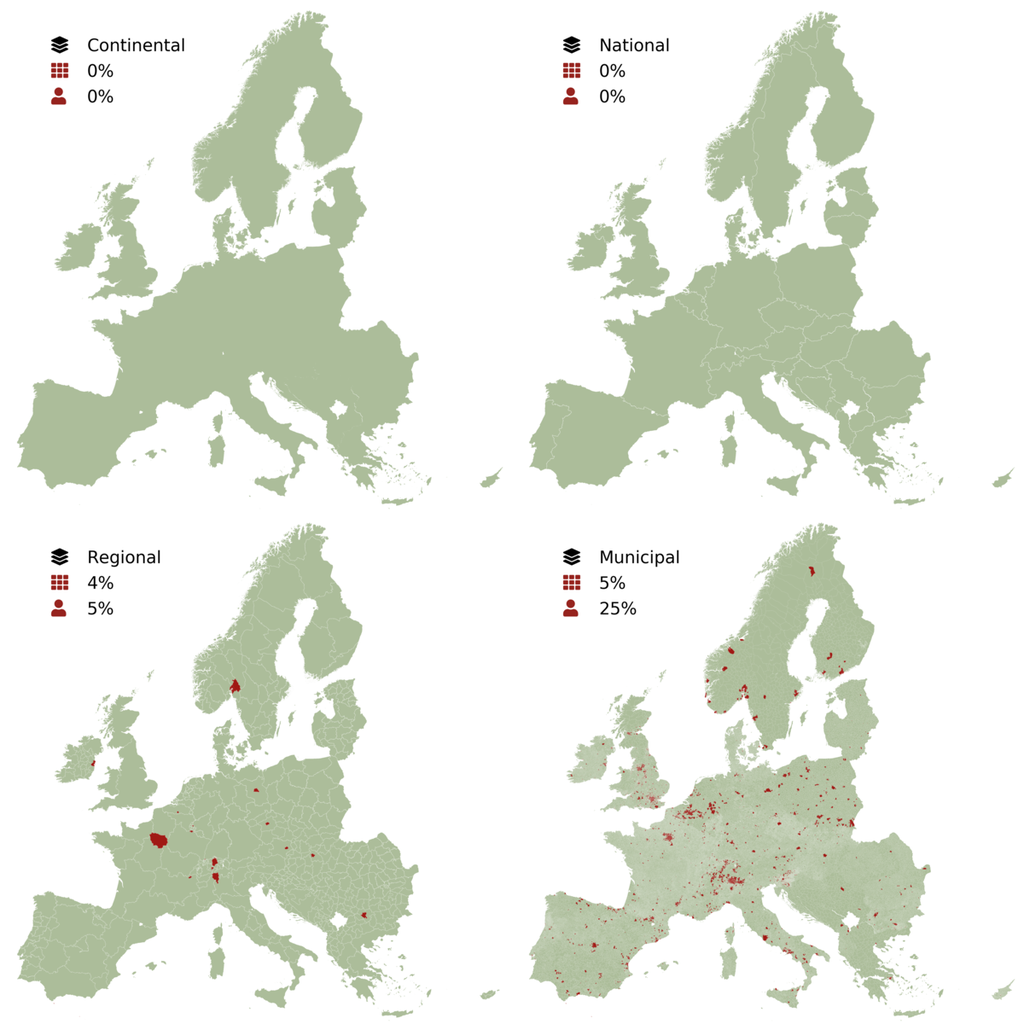

Figure 4: Administrative units where the technical-social potential exceeds electricity demand (light/green) and where it does not (dark/red), on all four administrative levels. For each level the text box furthermore shows from top to bottom: the name of the level, the fraction of undersupplied administrative units, and the fraction of the European population living in undersupplied administrative units.

Applying **municipal level** electricity autarky, about 75% of the population lives in the 95% of municipalities where the technical-social potential exceeds current demand. The majority of those undersupplied — 89% — live in municipalities with a population density above 1000 people per km<sup>2</sup>. According to the DEGURBA definition, 83% of the affected population lives in cities, 15% in towns and suburbs, and only 2% lives in rural areas. In undersupplied rural municipalities, national parks or natural reserves often cover a large share of the area, making it impossible to supply even a small population with sufficient amounts of renewable electricity. A few municipalities, such as Dormanstown (UK), Fos-sur-Mer (France), or Deuna (Germany), are undersupplied because of electricity-intensive industries. Overall, however, whether the technical-social renewables potential is sufficient or not is almost exclusively a function of population density.

Figure 5 shows the ranges of technical-social potential for all countries when assuming autarky on the municipal level. It shows that for several countries, more than a quarter of the population lives in municipalities with insufficient potential. Should the actually realisable potential be lower than the technical-social potential — for example because of public opposition — more municipalities will have insufficient potentials. The figure also shows that there are very high relative potentials in Europe, with the median person living in a municipality with a potential almost twice as high as their current electricity demand.

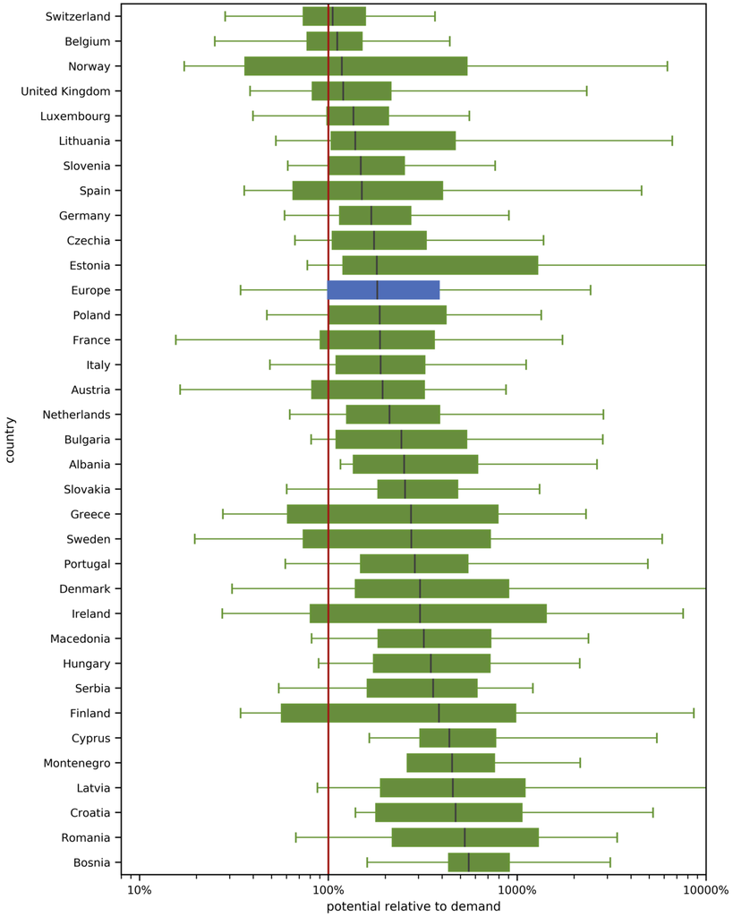

Figure 5: Distribution of technical-social potential per country and all Europe as experienced by the population when considering autarky on the municipal level: the boxes show the potential of the municipalities in which half of the population lives; centred around the median. Whiskers (green lines) show 95% of the population. Outliers (2.5% below and above each whisker) are not depicted.

## 4.3 Land footprint

Results of assessing the land area necessary for electricity autarky are shown in Table 3. Because we prioritise roof-mounted PV, overall share of land used is generally very low: on the continental and national levels it is always smaller than 1% of the non-built-up areas. On the regional and municipal levels there are some administrative units which need all or more of their non-built-up area, but on average the share of land used is very low as well. The reason for such limited land needs is the abundant source of electricity from roof-mounted PV which is in many cases able to fulfil the annual electricity demand on its own.

Table 3: Fractions of non-built-up land and roof surfaces used for electricity generation and share of demand supplied by roof-mounted PV when considering autarky. Values are given as average of all administrative units per level. Roof-mounted PV is prioritised.

| Level | Average land use [%] | Average roof space use [%] | Average roof-mounted PV share [%]: |
| --- | --- | --- | --- |
| Continental | 0 | 67 | 100 |
| National | 0 | 60 | 95 |
| Regional | 1 | 57 | 92 |
| Municipal | 2 | 48 | 96 |

Many electricity scenarios for Europe foresee much lower shares of PV and roof-mounted PV (see Discussion): in [72–74] for example, the share of PV is below 40%. When we consider 40% of the electricity demand as a hard limit for the generation of electricity from roof-mounted PV in each administrative unit, we obtain the results shown in Table 4. Compared to the unconstrained case, average share of land used is much higher on the regional and municipal level, where it increases on average by more than factor 2. For continental and national levels, it remains relatively low with only 1–2% of built-up areas needed on average, but up to 6% for single countries. Figure 6 visualises the share of non-built-up land used of all units on all four administrative levels when roof-mounted PV is limited to 40%. It shows how generation becomes more concentrated with smaller autarky levels, as generation moves closer to demand centres.

Table 4: Fractions of non-built-up land and roof surfaces used for electricity generation and share of demand supplied by roof-mounted PV when considering autarky. Values are given as average of all administrative units per level. Roof-mounted PV is prioritised, but prohibited to contribute more than 40% to the electricity demand in each administrative unit.

| Level | Average land use [%] | Average roof space use [%] | Average roof-mounted PV share [%]: |
| --- | --- | --- | --- |
| Continental | 1 | 27 | 40 |
| National | 2 | 28 | 39 |
| Regional | 4 | 28 | 39 |
| Municipal | 5 | 22 | 40 |

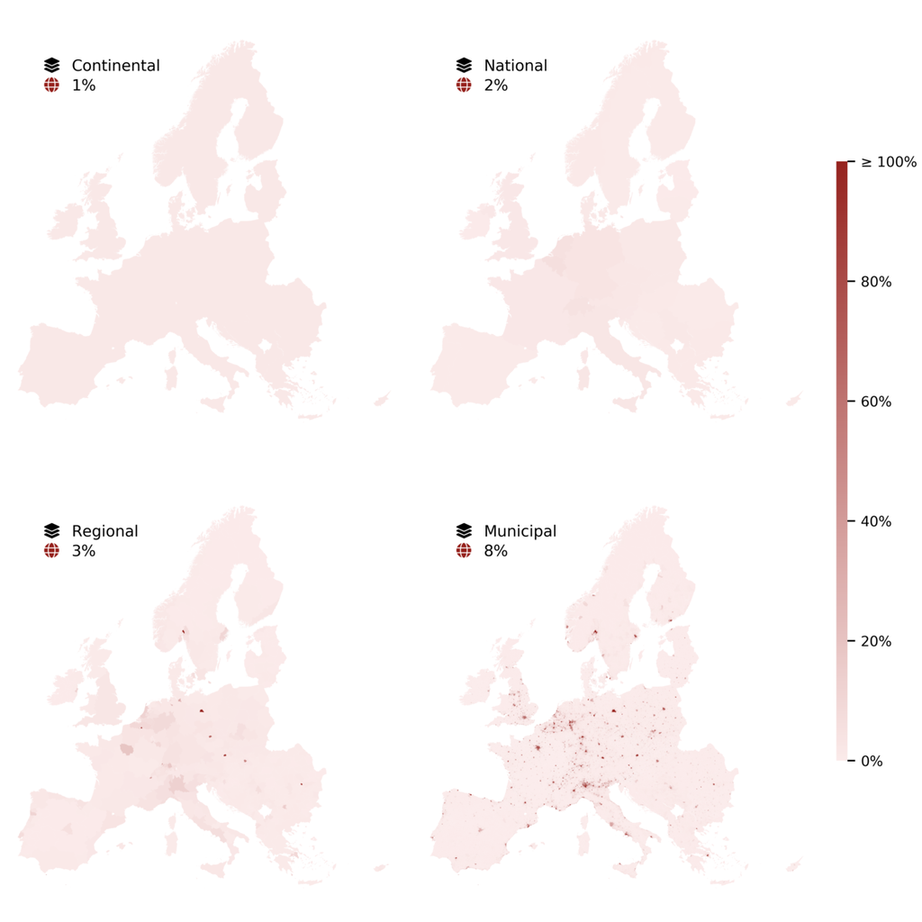

Figure 6: Fraction of non-built-up area needed for renewable power installations when demanding electricity autarky, for all administrative units on all four levels. The text labels on each level show the level’s name and the median fraction of non-built-up area based on population. For example, at the national level, 50% of Europe’s population lives in a country that requires less than 2% of its non-built-up area for renewable electricity autarky. On the municipal level, the same amount of people would see 8% of their non-built-up area used. Here, we assume farmland is not available for open field PV, we ignore offshore wind generation, and limit roof-mounted PV to 40% of demand.

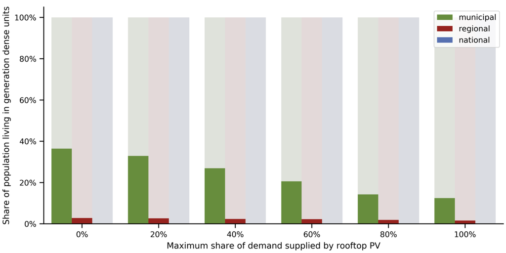

Figure 7: Share of the European population living in administrative units with high electricity generation density, i.e. units in which a third or more of the non-built-up land is used for wind turbines or open field PV, as a function of the maximum share of roof-mounted PV. The share is given for municipalities, regions, and countries, but is never larger than zero on the national level. For example, when a maximum of 40% of the electricity demand can be supplied by roof-mounted PV and municipalities are autarkic, almost 30% of the European population lives in municipalities in which a third or more of the non-built-up land is used for electricity generation. Total land excludes maritime regions and hence offshore wind is not considered. Roof-mounted PV is preferred over onshore wind farms and open field PV.

# 5 Discussion and Conclusion

We conclude that the potential for renewable electricity — a necessary condition for electricity autarky — is high enough for Europe as a whole as well as for each individual European country to supply themselves with 100% renewable electricity, without imports from abroad. In fact, the technical potential of each of the four considered technologies alone is higher than current European demand. But in some cases, the potential is too low to satisfy current demand on the municipal or regional levels. The potential is a binding constraint especially when applying social and ecological boundaries: in this case, up to 25% of the European population would live in areas that are not supplied with enough renewable electricity when considering autarky on municipal level. Areas which are unable to become autarkic are those with high population density, where non-built-up land sparse and less roof space is available per inhabitant. Other drivers of the possibility for autarky are electricity-intensive industries and, when kept free of energy installations, environmentally protected land. Both make autarky impossible for some municipalities, but their impact on all Europe, considering all municipalities, is small.

A second key finding in our study is that although most regions and municipalities have sufficiently high potentials to supply themselves, places with high population density must use large shares, sometimes approaching or exceeding 100%, of the remaining land for electricity generation if they seek to become autarkic. Increasing the geographical scope of electricity supply greatly relieves pressure on non-built-up land — which is often already under a great deal of pressure. On these higher geographical levels, generation does not need to happen in immediate spatial proximity of demand and can either be more equally distributed across the land, and/or moved to areas with fewer use conflicts. Both findings are sensitive to the assumed dispersion rate of roof-mounted photovoltaics: large potentials of this technology will improve the situation for smaller autarky levels as demand for non-built-up land is reduced.

## 5.1 Uncertainties and future research

There are trends in the European electricity system that can have a significant effect on our results. On the one hand there are technological improvements which will increase the potential of renewable electricity and thus help facilitate autarky on lower levels too. In our study, we used optimistic wind turbine and PV system parameters, which are ahead of the current state of the art, without being bold assumptions — but technology may evolve further than we expect today and thus pave the way for more autarky. The opposite case, i.e. that future technology is worse than today’s, appears highly unlikely.

On the other hand, there are divergent trends in electricity demand: energy efficiency is being pushed not only by proponents of autarky [3,6] but also by the European Commission [75]. If current policy plans are successful, European electricity demand would decrease over time. That would increase the chances for autarky on all levels, at least from a resource perspective. However, many expect that electricity demand will increase as the heat and transport sectors are electrified [76,77]. In its reference scenario for 2050 [72], the European Commission projects an increase in electricity demand of 25% in the period 2015–2050, assuming already ratified energy efficiency policies only. An increasing electricity demand would complicate autarky from a resource perspective. We can only speculate which trend will be dominant: technological improvements on the supply side and energy efficiency measures on the demand side, or rising electricity demand through electrification of the heat and transport sectors. Assuming a 25% increase in demand, supply technology enhancements in particular for photovoltaics are likely to be on par if not dominant [78,79], indicating that relative potentials might as well be higher in the future than those considered in this study.

The potential for renewable electricity we assessed is a necessary condition for electricity autarky, but not a sufficient one. In that sense our approach allows us to reject the possibility of autarky if demand is larger than the potential, but it does not allow us to confirm its feasibility. This means that areas for which we identified a potential higher than current demand may in fact not be able to reach autarky, because of further constraints and factors. To confirm the technical feasibility of autarky, we would have to take further technical factors into account, including distribution and transmission grid constraints, grid service requirements, and balancing of fluctuating renewables. Temporal fluctuations of renewable electricity can be balanced by spatial smoothing through larger grids or by temporal smoothing through storage — a point raised by critics of autarky electricity schemes (see Introduction). Importantly, we did not consider the problem of balancing, on both short and seasonal time scales, but this will greatly impact the feasibility of autarky on different levels.

We furthermore did not consider economic restrictions and instead used all of the available wind and solar resource, independent of its quality and cost. While solar and wind power generation is possible in most parts of Europe, they are expensive in many places, especially where the wind or solar resource is low. Hence, a realistic economic potential will be lower than the technical-social potential we used. Further, the method of balancing fluctuating renewable generation will contribute to total costs and the reduced potential of spatial balancing on lower geographical levels may complicate the feasibility of autarky. For our analysis, cost aspects were not relevant, but they must be considered by any analysis that confirms feasibility of electricity autarky in a certain area.

The third, and likely most uncertain type of restrictions are socio-political — in particular public and political acceptance of renewable power projects and grid expansion [32]. Not only is the impact of acceptance difficult to assess generally, but also it may vary drastically between different parts of Europe depending on local preferences and the style of decision-making, and it may vary over time. However, our main findings are not sensitive to this type of uncertainty. We show the relative difference between administrative levels which is largely driven by the geographic scale of each administrative level and the population distribution — a finding that is unaffected by any further social or economic constraints.

## 5.2 Policy implications

While renewable electricity resources are abundant in Europe, electricity autarky below the national level is not possible everywhere: some regions and municipalities have insufficient potential or need large fractions or all of their non-built-up land to become autarkic. A workaround for this issue could be to form electricity regions in which urban areas cooperate with their surrounding municipalities. In such electricity regions the surrounding municipalities could generate surplus electricity and export it into cities. The necessary size of such electricity regions is unknown and depends on the current and maximum density of the surrounding municipalities.

Even if forming electricity regions is an option, our results show how they would lead to high generation density in and around the urban area as autarky requires supply to be in close spatial proximity of demand. Even without electricity generation, these metropolitan areas are already under high pressure on non-built-up land and electricity generation would cause further pressure and potential land use conflicts, possibly aggravating any opposition against renewables and constraining their feasible expansion potential. Electricity autarky on the national level or above permits generating electricity relatively further away from demand. Electricity generation can hence be distributed more freely, but at the expense of the experienced freedom and local value creation that more local autarky is seen to hold the potential for.

Very high shares of building integrated PV, for example by using all rooftops for electricity generation, and/or by additionally using the façades of buildings, and/or by technological improvements and higher efficiencies would enable autarky also on regional and municipal levels, but only assuming balancing issues of electricity systems with very high PV shares, in some cases exceeding 80% can be handled. No study has investigated such extreme PV scenarios for all of Europe, but case studies have already shown this to be difficult for single regions and we expect that balancing costs would be high, if it would at all be feasible to store such vast amounts of solar electricity from summer to winter.

Instead, our results show that large shares of demand can be covered by locally generated renewable electricity, in all countries, regions and most municipalities of Europe. Full autarky, i.e. without any trading between areas, is not possible in the most densely populated regions, and hence a non-trivial share of the European population would be undersupplied if their municipality, and in a few cases, their region, declared itself electricity autarkic. In many areas, especially in and around larger cities, autarky is possible from a resource perspective, but it would come at the cost of high additional pressure on as yet not built-up land. Here, we have shown in which parts of Europe autarky would be at all possible and where not. Whether and where this is really attractive is a still open question.

# 6 Acknowledgements

The work of Tim Tröndle and Johan Lilliestam was supported by a European Research Council grant (TRIPOD project, grant agreement number 715132).

# 7 Declarations of interest

None.

# Bibliography

[1] Publications Office of the European Union, EU energy in figures : Statistical pocketbook 2017, European Union, Luxembourg, 2017. doi:10.2833/80717.

[2] B. Abegg, Energy Self-sufficient Regions in the European Alps, Mountain Research and Development. 31 (2011) 367–371. doi:10.1659/MRD-JOURNAL-D-11-00056.1.

[3] M.O. Müller, A. Stämpfli, U. Dold, T. Hammer, Energy autarky: A conceptual framework for sustainable regional development, Energy Policy. 39 (2011) 5800–5810. doi:10.1016/j.enpol.2011.04.019.

[4] M. Engelken, B. Römer, M. Drescher, I. Welpe, Transforming the energy system: Why municipalities strive for energy self-sufficiency, Energy Policy. 98 (2016) 365–377. doi:10.1016/j.enpol.2016.07.049.

[5] F. Ecker, U. Hahnel, H. Spada, Promoting decentralized sustainable energy systems in different supply scenarios: The role of autarky aspiration, Frontiers in Energy Research. 5 (2017). doi:10.3389/fenrg.2017.00014.

[6] C. Rae, F. Bradley, Energy autonomy in sustainable communities—A review of key issues, Renewable and Sustainable Energy Reviews. 16 (2012) 6497–6506. doi:10.1016/j.rser.2012.08.002.

[7] G. Czisch, Szenarien zur zukünftigen Stromversorgung - Kostenoptimierte Variationen zur Versorgung Europas und seiner Nachbarn mit Strom aus erneuerbaren Energien, Universität Kassel, 2005. https://kobra.bibliothek.uni-kassel.de/bitstream/urn:nbn:de:hebis:34-200604119596/1/DissVersion0502.pdf.

[8] A. Patt, N. Komendantova, A. Battaglini, J. Lilliestam, Regional integration to support full renewable power deployment for Europe by 2050, Environmental Politics. 20 (2011) 727–742. doi:10.1080/09644016.2011.608537.

[9] F. Steinke, P. Wolfrum, C. Hoffmann, Grid vs. Storage in a 100% renewable Europe, Renewable Energy. 50 (2013) 826–832. doi:10.1016/j.renene.2012.07.044.

[10] E. Schmid, B. Knopf, Quantifying the long-term economic benefits of European electricity system integration, Energy Policy. 87 (2015) 260–269. doi:10.1016/j.enpol.2015.09.026.

[11] D.P. Schlachtberger, T. Brown, S. Schramm, M. Greiner, The benefits of cooperation in a highly renewable European electricity network, Energy. 134 (2017) 469–481. doi:10.1016/j.energy.2017.06.004.

[12] J. Schmidt, M. Schönhart, M. Biberacher, T. Guggenberger, S. Hausl, G. Kalt, S. Leduc, I. Schardinger, E. Schmid, Regional energy autarky: Potentials, costs and consequences for an Austrian region, Energy Policy. 47 (2012) 211–221. doi:10.1016/j.enpol.2012.04.059.

[13] A. Battaglini, J. Lilliestam, A. Haas, A. Patt, Development of SuperSmart Grids for a more efficient utilisation of electricity from renewable sources, Journal of Cleaner Production. 17 (2009) 911–918. doi:10.1016/j.jclepro.2009.02.006.

[14] S. Funcke, D. Bauknecht, Typology of centralised and decentralised visions for electricity infrastructure, Utilities Policy. 40 (2016) 67–74. doi:10.1016/j.jup.2016.03.005.

[15] H. Scheer, Der energethische Imperativ, Antje Kunstmann, 2012.

[16] J. Lilliestam, S. Hanger, Shades of green: Centralisation, decentralisation and controversy among European renewable electricity visions, Energy Research & Social Science. 17 (2016) 20–29. doi:10.1016/j.erss.2016.03.011.

[17] P. Buschmann, P. Moser, S. Roth, K. Schenk, 100 RE Regions in Germany, Europe and the world, IdE Institut dezentrale Energietechnologien gGmbH, Kassel, 2014. http://www.100-res-communities.eu/ita/content/download/149444/2441805/file/Good-Practice_Broschuere_Inhalt_Web.pdf.

[18] 100% RES Communities, 100-RES-COMMUNITIES Steps Towards 100% Renewable Energy at Local Level In Europe, 100% RES Communities, 2015. http://www.100-res-communities.eu/content/download/153639/2495799/file/100RES-GB-Web.pdf (accessed May 27, 2019).

[19] 100ee Regionen-Netzwerk, REGIONAL VOICES: SHAPING THE ENERGY TURNAROUND! Communiqué for a Decentralized Energy Turnaround, 100ee Regionen-Netzwerk, 2015. http://www.100-ee.de/fileadmin/redaktion/100ee/Bilder/100ee_Europa/Kommunique_ENG.pdf (accessed August 23, 2018).

[20] European Commission, COMMUNICATION FROM THE COMMISSION TO THE EUROPEAN PARLIAMENT, THE COUNCIL, THE EUROPEAN ECONOMIC AND SOCIAL COMMITTEE, THE COMMITTEE OF THE REGIONS AND THE EUROPEAN INVESTMENT BANK A Framework Strategy for a Resilient Energy Union with a Forward-Looking Climate Change Policy, European Commission, Brussels, 2015. https://eur-lex.europa.eu/legal-content/EN/TXT/?uri=COM:2015:80:FIN (accessed August 1, 2018).

[21] ENTSO-E, TYNDP 2018 Executive Report Connecting Europe: Electricity 2025 - 2030 - 2040 Version for public consultation, ENTSO-E, 2018. https://tyndp.entsoe.eu/Documents/TYNDP%20documents/TYNDP2018/consultation/Main%20Report/TYNDP2018_Executive%20Report.pdf (accessed August 23, 2018).

[22] A. Cho, Energy’s Tricky Tradeoffs, Science. 329 (2010) 786–787. doi:10.1126/science.329.5993.786.

[23] M. Hoogwijk, B. de Vries, W. Turkenburg, Assessment of the global and regional geographical, technical and economic potential of onshore wind energy, Energy Economics. 26 (2004) 889–919. doi:10.1016/j.eneco.2004.04.016.

[24] European Environment Agency, Europe’s onshore and offshore wind energy potential, 2009. https://www.eea.europa.eu/publications/europes-onshore-and-offshore-wind-energy-potential (accessed October 9, 2017).

[25] R. Buffat, S. Grassi, M. Raubal, A scalable method for estimating rooftop solar irradiation potential over large regions, Applied Energy. 216 (2018) 389–401. doi:10.1016/j.apenergy.2018.02.008.

[26] P.R. Defaix, W.G.J.H.M. van Sark, E. Worrell, E. de Visser, Technical potential for photovoltaics on buildings in the EU-27, Solar Energy. 86 (2012) 2644–2653. doi:10.1016/j.solener.2012.06.007.

[27] R. McKenna, S. Hollnaicher, P. Ostman v. d. Leye, W. Fichtner, Cost-potentials for large onshore wind turbines in Europe, Energy. 83 (2015) 217–229. doi:10.1016/j.energy.2015.02.016.

[28] T. Huld, K. Bodis, I.P. Pascua, E. Dunlop, N. Taylor, A. Jäger-Waldau, The Rooftop Potential for PV Systems in the European Union to deliver the Paris Agreement, (2018). http://www.europeanenergyinnovation.eu/Articles/Spring-2018/The-Rooftop-Potential-for-PV-Systems-in-the-European-Union-to-deliver-the-Paris-Agreement (accessed June 25, 2018).

[29] R. McKenna, S. Hollnaicher, W. Fichtner, Cost-potential curves for onshore wind energy: A high-resolution analysis for Germany, Applied Energy. 115 (2014) 103–115. doi:10.1016/j.apenergy.2013.10.030.

[30] N. Fueyo, Y. Sanz, M. Rodrigues, C. Montañés, C. Dopazo, High resolution modelling of the on-shore technical wind energy potential in Spain, Wind Energy. 13 (2010) 717–726. doi:10.1002/we.392.

[31] S.H. Siyal, U. Mörtberg, D. Mentis, M. Welsch, I. Babelon, M. Howells, Wind energy assessment considering geographic and environmental restrictions in Sweden: A GIS-based approach, Energy. 83 (2015) 447–461. doi:10.1016/j.energy.2015.02.044.

[32] S. Höltinger, B. Salak, T. Schauppenlehner, P. Scherhaufer, J. Schmidt, Austria’s wind energy potential – A participatory modeling approach to assess socio-political and market acceptance, Energy Policy. 98 (2016) 49–61. doi:10.1016/j.enpol.2016.08.010.

[33] V. Quaschning, Systemtechnik einer klimaverträglichen Elektrizitätsversorgung in Deutschland für das 21. Jahrhundert, Als Ms. gedr, VDI-Verl, Düsseldorf, 2000. http://www.volker-quaschning.de/downloads/Klima2000.pdf.

[34] K. Mainzer, K. Fath, R. McKenna, J. Stengel, W. Fichtner, F. Schultmann, A high-resolution determination of the technical potential for residential-roof-mounted photovoltaic systems in Germany, Solar Energy. 105 (2014) 715–731. doi:10.1016/j.solener.2014.04.015.

[35] D. Assouline, N. Mohajeri, J.-L. Scartezzini, Quantifying rooftop photovoltaic solar energy potential: A machine learning approach, Solar Energy. 141 (2017) 278–296. doi:10.1016/j.solener.2016.11.045.

[36] T. Jäger, R. McKenna, W. Fichtner, The feasible onshore wind energy potential in Baden-Württemberg: A bottom-up methodology considering socio-economic constraints, Renewable Energy. 96 (2016) 662–675. doi:10.1016/j.renene.2016.05.013.

[37] J. Ordóñez, E. Jadraque, J. Alegre, G. Martínez, Analysis of the photovoltaic solar energy capacity of residential rooftops in Andalusia (Spain), Renewable and Sustainable Energy Reviews. 14 (2010) 2122–2130. doi:10.1016/j.rser.2010.01.001.

[38] A. Strzalka, N. Alam, E. Duminil, V. Coors, U. Eicker, Large scale integration of photovoltaics in cities, Applied Energy. 93 (2012) 413–421. doi:10.1016/j.apenergy.2011.12.033.

[39] M.C. Brito, N. Gomes, T. Santos, J.A. Tenedório, Photovoltaic potential in a Lisbon suburb using LiDAR data, Solar Energy. 86 (2012) 283–288. doi:10.1016/j.solener.2011.09.031.

[40] L. Bergamasco, P. Asinari, Scalable methodology for the photovoltaic solar energy potential assessment based on available roof surface area: Further improvements by ortho-image analysis and application to Turin (Italy), Solar Energy. 85 (2011) 2741–2756. doi:10.1016/j.solener.2011.08.010.

[41] eurostat, Regions in the European Union, 2015. http://ec.europa.eu/eurostat/web/gisco/geodata/reference-data/administrative-units-statistical-units (accessed October 19, 2017).

[42] GADM, Global Administrative Areas, (2018). http://gadm.org/ (accessed May 8, 2018).

[43] S. Claus, N. De Hauwere, B. Vanhoorne, F. Souza Dias, P. Oset García, F. Hernandez, J. Mees, Maritime Boundaries Geodatabase: Maritime Boundaries and Exclusive Economic Zones (200NM), version 10, (2018). doi:10.14284/312.

[44] World Energy Council, 2007 Survey of Energy Resources, World Energy Council, 2007.

[45] European Environment Agency, How much bioenergy can Europe produce without harming the environment?, 2006. https://www.eea.europa.eu/publications/eea_report_2006_7 (accessed October 11, 2017).

[46] European Space Agency, GlobCover 2009, (2010). http://due.esrin.esa.int/page_globcover.php (accessed September 19, 2017).

[47] H.I. Reuter, A. Nelson, A. Jarvis, An evaluation of void-filling interpolation methods for SRTM data, International Journal of Geographical Information Science. 21 (2007) 983–1008. http://www.tandfonline.com/doi/abs/10.1080/13658810601169899 (accessed September 19, 2017).

[48] J.J. Danielson, D.B. Gesch, Global multi-resolution terrain elevation data 2010 (GMTED2010), US Geological Survey, 2011.

[49] C. Amante, B. Eakins, Arc-Minute Global Relief Model: Procedures, Data Sources and Analysis, (2009). doi:10.7289/V5C8276M.

[50] UNEP-WCMC, IUCN, Protected Planet: The World Database on Protected Areas (WDPA), Protected Planet. (2018). https://www.protectedplanet.net/ (accessed February 2, 2018).

[51] S. Ferri, A. Siragusa, F. Sabo, M. Pafi, M. Halkia, The European Settlement Map 2017 Release; Methodology and output of the European Settlement Map (ESM2p5m), JRC, 2017. doi:10.2760/780799.

[52] D.S. Ryberg, M. Robinius, D. Stolten, Evaluating Land Eligibility Constraints of Renewable Energy Sources in Europe, Energies. 11 (2018) 1246. doi:10.3390/en11051246.

[53] Swiss Federal Office of Energy, Sonnendach.ch, (2018). http://www.sonnendach.ch.

[54] Swiss Federal Office of Energy, Sonnendach.ch: Berechnung von Potenzialen in Gemeinden, Bundesamt für Energie, 2019. https://www.bfe.admin.ch/bfe/de/home/versorgung/statistik-und-geodaten/geoinformation/geodaten/solar/solarenergie-eignung-hausdach.html (accessed May 27, 2019).

[55] I. Staffell, S. Pfenninger, Using bias-corrected reanalysis to simulate current and future wind power output, Energy. 114 (2016) 1224–1239. doi:10.1016/j.energy.2016.08.068.

[56] M.Z. Jacobson, V. Jadhav, World estimates of PV optimal tilt angles and ratios of sunlight incident upon tilted and tracked PV panels relative to horizontal panels, Solar Energy. 169 (2018) 55–66. doi:10.1016/j.solener.2018.04.030.

[57] S. Pfenninger, I. Staffell, Long-term patterns of European PV output using 30 years of validated hourly reanalysis and satellite data, Energy. 114 (2016) 1251–1265. doi:10.1016/j.energy.2016.08.060.

[58] H.Z. Al Garni, A. Awasthi, Chapter 2 - Solar PV Power Plants Site Selection: A Review, in: I. Yahyaoui (Ed.), Advances in Renewable Energies and Power Technologies, Elsevier, 2018: pp. 57–75. doi:10.1016/B978-0-12-812959-3.00002-2.

[59] Council Directive 92/43/EEC of 21 May 1992 on the conservation of natural habitats and of wild fauna and flora, 1992. http://data.europa.eu/eli/dir/1992/43/oj/eng (accessed July 12, 2018).

[60] Directive 2009/147/EC of the European Parliament and of the Council of 30 November 2009 on the conservation of wild birds, 2010. http://data.europa.eu/eli/dir/2009/147/oj/eng (accessed July 12, 2018).

[61] Open Power System Data, Data Package Time series, (2018). doi:10.25832/time_series/2018-06-30.

[62] JRC, CIESIN, GHS population grid, derived from GPW4, multitemporal (1975, 1990, 2000, 2015), (2015). http://data.europa.eu/89h/jrc-ghsl-ghs_pop_gpw4_globe_r2015a.

[63] European Environment Agency, European Union Emissions Trading System (EU ETS) data from EUTL, (2018). https://www.eea.europa.eu/data-and-maps/data/european-union-emissions-trading-scheme-6 (accessed August 14, 2018).

[64] Ecorys, Study on European Energy-Intensive Industries – The Usefulness of Estimating Sectoral Price Elasticities, Ecorys Research and Consulting, Cambridge, 2009.

[65] M. Paulus, F. Borggrefe, The potential of demand-side management in energy-intensive industries for electricity markets in Germany, Applied Energy. 88 (2011) 432–441. doi:10.1016/j.apenergy.2010.03.017.

[66] Eurofer, Total crude steel production, (2015).

[67] M. Klobasa, Dynamische Simulation eines Lastmanagements und Integration von Windenergie in ein Elektrizitätsnetz auf Landesebene unter regelungstechnischen und Kostengesichtspunkten, ETH Zürich, 2007.

[68] EAA, Aluminium sector in Europe 2011, (2012).

[69] Eurochlor, Chlorine industry review 2013-2014, (2014).

[70] Cembuerau, Key facts & figures, (2015).

[71] L. Dijkstra, H. Poelman, A harmonised definition of cities and rural areas: The new degree of urbanisation, European Commission, 2014.

[72] European Commission, EU Reference Scenario 2016 – Energy, transport and GHG emmissions: Trends to 2050, Office for official publications of the european communities, Luxembourg, 2016.

[73] Fraunhofer IEE, Analyse eines europäischen -95%-Klimazielszenarios über mehrere Wetterjahre, 2017. http://www.energieversorgung-elektromobilitaet.de/includes/reports/Auswertung_7Wetterjahre_95Prozent_FraunhoferIWES.pdf (accessed February 7, 2018).

[74] Greenpeace, EREC, Energy [r]Evolution – A Sustainable EU 27 Energy Outlook, 2012. https://www.greenpeace.org/archive-eu-unit/en/Publications/2012/ER-2012/ (accessed May 27, 2019).

[75] European Commission, Energy Efficiency Directive 2012/27/EU, 2012. http://eur-lex.europa.eu/legal-content/EN/TXT/?uri=CELEX%3A32012L0027 (accessed December 12, 2017).

[76] T. Boßmann, I. Staffell, The shape of future electricity demand: Exploring load curves in 2050s Germany and Britain, Energy. 90 (2015) 1317–1333. doi:10.1016/j.energy.2015.06.082.

[77] D. Connolly, Heat Roadmap Europe: Quantitative comparison between the electricity, heating, and cooling sectors for different European countries, Energy. 139 (2017) 580–593. doi:10.1016/j.energy.2017.07.037.

[78] International Energy Agency, Technology Roadmap: Solar Photovoltaic Energy, OECD Publishing, 2010. doi:10.1787/9789264088047-en.

[79] S.P. Philipps, W. Warmuth, Photovoltaics Report, Fraunhofer ISE, 2017.